# Predicting digits from scribbles

Severin Hauenstein

12/18/2018

I am sure there are other (perhaps better) R packages to fit artificial neural networks (ANNs), especially if you want to fit multi-hidden-layer NNs. But since we are fitting only single-hidden layer ANNs, we’ll give this one a shot:

```r
library(nnet)
```

## Helper functions

The following is a function to compute error rates comparing true labels and predictions.

```r
error.rate <- function(fitted.model, testdata, pred.type = "class"){
  preds <- predict(fitted.model, testdata, type = pred.type)
  if(is.list(preds)) preds <- preds[[1]]
  total <- sum(as.integer(as.character(preds)) != testdata[,1])/NROW(testdata)
  partitioned <- sapply(sort(unique(testdata[,1])), function(x)
    sum(as.integer(as.character(preds[testdata[,1] == x])) !=
          testdata[testdata[,1] == x,1])/
      NROW(testdata[testdata[,1] == x,]))
  names(partitioned) <- as.character(sort(unique(testdata[,1])))
  return(c(total = total, partitioned))
}
```

## Training and test data

After registering, we can download 60,000 images of 28x28 pixel digit scribbles from https://www.kaggle.com/c/digit-recognizer/data To speed up the runtimes of our ANNs, we’ll first select random subsets as training and test data.

#### Visualising the scribbles

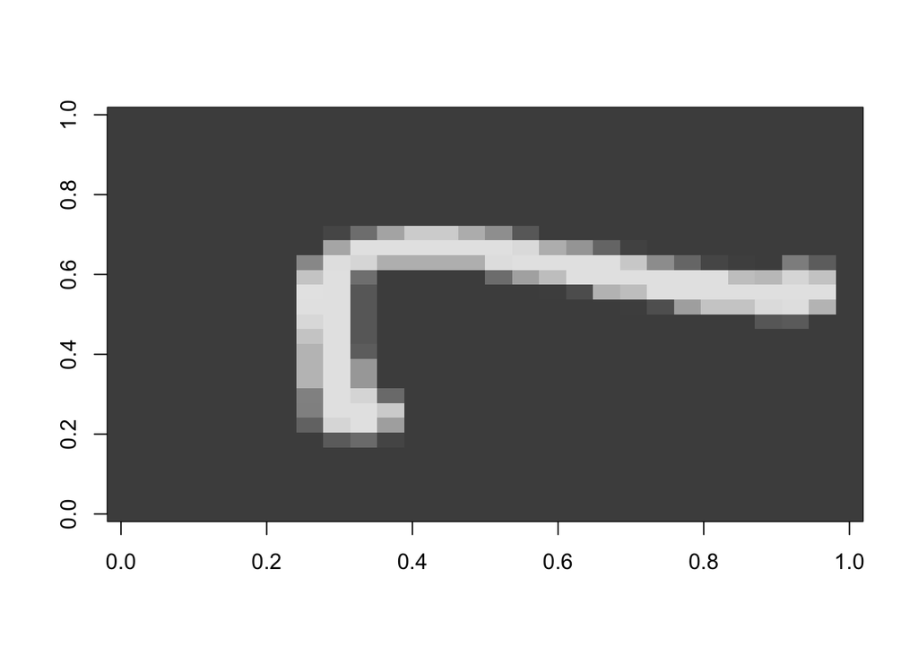

```r
# Create a 28*28 matrix with pixel color values
m = matrix(unlist(train[10,-1]), nrow = 28, byrow = TRUE)

# Plot that matrix
image(m,col=grey.colors(255))
```

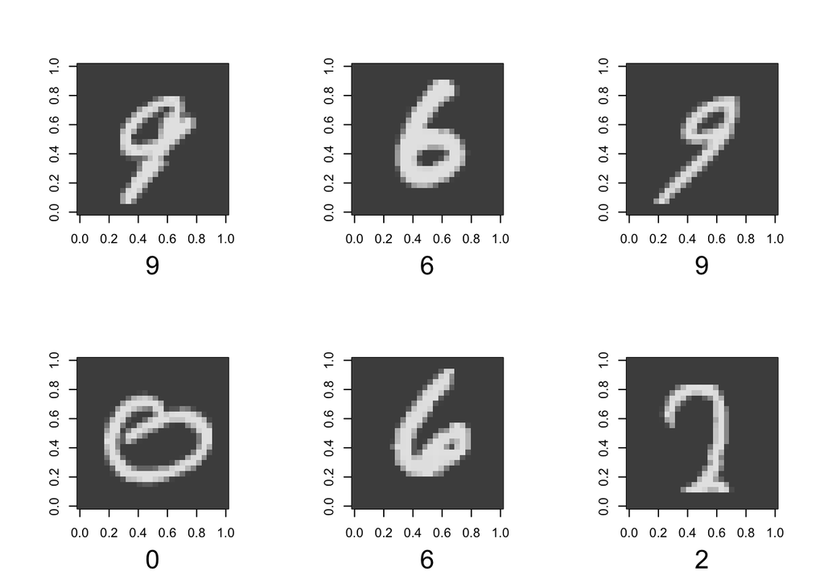

```r
# reverses (rotates the matrix)
rotate <- function(x) t(apply(x, 2, rev))

# Plot some of the images
par(mfrow=c(2,3), cex.lab = 2, pty = "s")
lapply(1:6,
       function(x) image(
         rotate(matrix(unlist(train[x,-1]),nrow = 28, byrow = TRUE)),
         col=grey.colors(255),
         xlab=train[x,1]
       )
)
```

## Fitting single-hidden-layer ANNs

#### Increasing the number of hidden-layer nodes

1. We start simple with 1 node in our hidden layer. Other tuning parameters are kept at there default, we’ll get to those later.

```r
system.time(
fann01 <- nnet::nnet(as.factor(label) ~ ., data = train,
                size = 1, MaxNWts = 805)
)
```

```
##    user  system elapsed
##  21.763   0.226  22.111
```

```r
error.rate(fann01, test, pred.type = "class")
```

```
##      total          0          1          2          3          4
## 0.79100000 1.00000000 0.01408451 1.00000000 1.00000000 0.99815838
##          5          6          7          8          9
## 1.00000000 0.02615694 1.00000000 1.00000000 1.00000000
```

2. Pretty bad, so let’s increase the number of nodes in the hidden layer to 5. You’ll notice we need to increase the maximum allowed number of weights as well.

```r
system.time(
fann02 <- nnet::nnet(as.factor(label) ~ ., data = train,
                size = 5, MaxNWts = 20000)
)
```

```
##    user  system elapsed
##  62.311   0.383  63.027
```

```r
error.rate(fann02, test, pred.type = "class")
```

```
##     total         0         1         2         3         4         5
## 0.5464000 0.1038136 0.1197183 0.9646365 1.0000000 0.9834254 1.0000000
##         6         7         8         9
## 0.8048290 0.2256214 0.1247401 0.1753653
```

3. Much better, but for some digits, still really bad. Let’s increase the number of nodes to 10.

```r
system.time(
fann03 <- nnet::nnet(as.factor(label) ~ ., data = train,
                size = 10, MaxNWts = 20000)
)
```

```
##    user  system elapsed
## 161.025   0.528 162.028
```

```r
error.rate(fann03, test, pred.type = "class")
```

```
##      total          0          1          2          3          4
## 0.26200000 0.08262712 0.04577465 0.24165029 0.36875000 0.22467772
##          5          6          7          8          9
## 0.49776786 0.17505030 0.13001912 0.39501040 0.53235908
```

#### Convergence

Let’s not increase the number of hidden-layer nodes further without checking other tuning parameters of our ANN. What about convergence? Was the maximum number of iterations reached before the decrease in the loss function has leveled off?

```r
fann01$convergence
```

```
## [1] 1
```

```r
fann02$convergence
```

```
## [1] 1
```

```r
fann03$convergence
```

```
## [1] 1
```

The ANNs have not converged!

So let’s take `fann03`, but increase `maxit` to 500.

```r
system.time(
fann04 <- nnet::nnet(as.factor(label) ~ ., data = train,
                size = 10, MaxNWts = 20000, maxit = 500)
)
```

```
##     user   system  elapsed
##  923.335    1.898 3164.383
```

```r
error.rate(fann04, test, pred.type = "class")
```

```
##      total          0          1          2          3          4
## 0.22400000 0.10169492 0.04929577 0.27897839 0.20833333 0.17679558
##          5          6          7          8          9
## 0.34151786 0.26156942 0.15296367 0.29937630 0.41544885
```

Improved, but still no convergence. But time seems better invested in increasing the number of nodes.

#### Training data size

Increasing the training dataset is another way to improve the ANN. Let’s refit `fann03`, but with `train_n = 20000`.

```r
indeces_xxl <- sample(NROW(digit_data), size = 20000 + test_n)
train_xxl <- digit_data[indeces_xxl[1:20000],]
test_xxl <- digit_data[indeces_xxl[(20000 + 1):(20000 + test_n)],]
system.time(
fann05 <- nnet::nnet(as.factor(label) ~ ., data = train_xxl,
                size = 10, MaxNWts = 20000, maxit = 100)
)
```

```
##    user  system elapsed
## 258.474   1.267 261.500
```

```r
error.rate(fann05, test, pred.type = "class")
```

```
##     total         0         1         2         3         4         5
## 0.2200000 0.1588983 0.0721831 0.1866405 0.1958333 0.1381215 0.2857143
##         6         7         8         9
## 0.1307847 0.1701721 0.4469854 0.4655532
```

It seems as if 10000 data points are sufficient for the current problem at hand.

#### Checking the (computationally feasible) limits

As a last exercise we increase the number of nodes to 30 and set the maximum number of iterations to 500.

```r
system.time(
fann06 <- nnet::nnet(as.factor(label) ~ ., data = train,
                size = 30, MaxNWts = 25000, maxit = 500)
)
```

```
##      user    system   elapsed
## 11664.282    37.358 48622.567
```

```r
error.rate(fann06, test, pred.type = "class")
```

```
##      total          0          1          2          3          4
## 0.13780000 0.09110169 0.03873239 0.14734774 0.19375000 0.15101289
##          5          6          7          8          9
## 0.21205357 0.12877264 0.12619503 0.17671518 0.13361169
```

## What about random forest?

The tuning options of ANNs seem endless. Here, we have just scratched the surface. More on ANNs in the two statistcs cafe sessions to come. Random forests are quite the opposite with regards to tuning options. Sure, we can play with the number of predictors to consider at each split or the number of trees to grow or the decision tree algorithm we use. But overall the differences seem almost negligible.

Random forests are not famous for their application in ‘image recognition problems’, but let’s try it anyways. At least they are quite fast using the `ranger` package:

```r
system.time(
franger <- ranger::ranger(as.factor(train$label) ~ ., data = train, num.trees = 1000)
)
```

```
##    user  system elapsed
## 158.388   1.005  49.249
```

```r
error.rate(franger, test, pred.type = "response")
```

```
##      total          0          1          2          3          4
## 0.04960000 0.01906780 0.01760563 0.04715128 0.06875000 0.04788214
##          5          6          7          8          9
## 0.07366071 0.03219316 0.04971319 0.07276507 0.07515658
```

What if we increase the number of data points in the training set?

```r
system.time(
franger_xxl <- ranger::ranger(as.factor(label) ~ ., data = train_xxl, num.trees = 1000)
)
```

```
##    user  system elapsed
## 359.881   1.741  96.914
```

```r
error.rate(franger, test_xxl, pred.type = "response")
```

```
##      total          0          1          2          3          4
## 0.03600000 0.01434426 0.01766784 0.02674897 0.05620155 0.02994012
##          5          6          7          8          9
## 0.05694761 0.01775148 0.03896104 0.04356846 0.06302521
```